# Monte Carlo Simulation

Gerko Vink and Erik-Jan van Kesteren

Statistical Programming with R

## Packages and functions that we use

```r
library(dplyr)    # Data manipulation
library(magrittr) # Pipes
library(stringr)  # For counting substrings
library(ggplot2)  # Plotting suite
```

# “feel like a god at your own computer”

## What is it?

With Monte Carlo methods we can compute expectations: what do we expect to happen to a particular sample quantity (such as the mean or a p-value) upon repeated sampling?

It builds upon the principles of inferential statistics and needs:

- A large set of numbers (e.g. an infinite population) or a theoretical distribution
- A way to sample randomly from that large set

It works by repetitively sampling from a population while varying the input, but keeping the method consistent.

## Why do it?

- evaluate how a statistical method performs in different situations
- calculate the power of a particular test based on some (violation of) assumptions
- estimate the probability of a complex event by simulating that event

# Some probability intuition

## Uncertainty, estimation, repeated sampling

- John travels to and from work by train every day:
  - In the past 10 years his train has been delayed 12 times
  - $P(\text{delay}) = \frac{12}{2\times3650} \approx .0016$
- Bill travels to and from work by train every week:
  - In the past year his train has been delayed 50 times
  - $P(\text{delay}) = \frac{50}{2\times52} \approx .481$
- Claire travels by train very occasionally
  - Out of the last 3 trips, two trips were delayed
  - $P(\text{delay}) = \frac{2}{3} \approx 0.667$

Who should be most confident about their estimate of delay probability?

## Law of large numbers

### Bernouilli’s Theorem (1713):

In repeated `independent` experiments

1. with the same `true` probability $p$ of a particular outcome in each experiment
2. when repeated over a large number of times
3. the average over the results for all these repetitions
4. will converge to the `true` probability $p$

So if we replicate the same procedure an infinite number of times, the difference between our estimate and the true value would be zero.

The experiments **must be independent**, i.e., the event probability in one trial does not depend on other trials.

# Let’s throw some dice.

## Law of large numbers

```r
set.seed(123)
x <- sample(1:6, 10, prob = rep(1/6, 6), replace = TRUE)
prop.table(table(x))
```

```
## x
##   1   2   3   4   5   6
## 0.3 0.1 0.1 0.2 0.2 0.1
```

```r
x <- sample(1:6, 100, prob = rep(1/6, 6), replace = TRUE)
prop.table(table(x))
```

```
## x
##    1    2    3    4    5    6
## 0.15 0.17 0.16 0.21 0.14 0.17
```

## More samples!

```r
x <- sample(1:6, 10000, prob = rep(1/6, 6), replace = TRUE)
prop.table(table(x))
```

```
## x
##      1      2      3      4      5      6
## 0.1616 0.1683 0.1663 0.1713 0.1663 0.1662
```

```r
x <- sample(1:6, 1000000, prob = rep(1/6, 6), replace = TRUE)
prop.table(table(x))
```

```
## x
##        1        2        3        4        5        6
## 0.166610 0.167284 0.166763 0.166686 0.166458 0.166199
```

## Estimating the probability of an event

### What is the probability of getting 123 in a row?

```r
charx <- paste(x, collapse = "")

estprob  <- str_count(charx, "123") / 1e6
trueprob <- (1/6)^3

cat(estprob,"\n", trueprob, sep = "")
```

```
## 0.004635
## 0.00462963
```

# Monte Carlo simulation

## Throwing 100000 dice 100 times

```r
# Initialise results object
result <- list()

# repeat K times
for (i in 1:100) {

  # generate a dataset of interest
  dataset <- sample(1:6, 100000, prob = rep(1/6, 6), replace = TRUE)

  # optional: perform your method on this dataset

  # Save the values you are interested in
  result[[i]] <- dataset

}

# Aggregate your results
probs <- sapply(result, function(x) prop.table(table(x)))

# Display output
rowMeans(probs)
```

```
##         1         2         3         4         5         6
## 0.1665194 0.1666168 0.1668015 0.1666164 0.1666844 0.1667615
```

## Unfair dice

```r
result <- list()
for (i in 1:1000) {
  result[[i]] <- sample(1:6,
                        size = 1000,
                        prob = c(.01, .04, .1, .15, .2, .5),
                        replace = TRUE)
} # 1000 trials
probs <- sapply(result, function(x) prop.table(table(x)))
rowMeans(probs)
```

```
##        1        2        3        4        5        6
## 0.010030 0.040065 0.099689 0.149490 0.200011 0.500715
```

# Power calculation through simulation

## Power simulations

### Power

The probability of detecting an effect if there is in fact a true effect.

### What affects power?

- Larger true effect means larger power (easier to detect the effect)
- Larger sample size means larger power (less uncertainty, smaller standard errors)
- Some methods are more powerful than others

## Power simulation

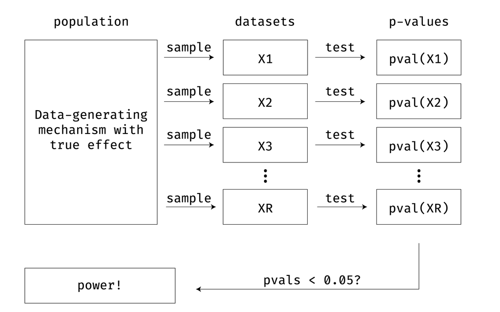

## Example power simulation

### Research question

What happens to the power of an independent-samples t-test if we measure on a 5-point scale instead of a continuous outcome?

## Measuring on 5-point scale

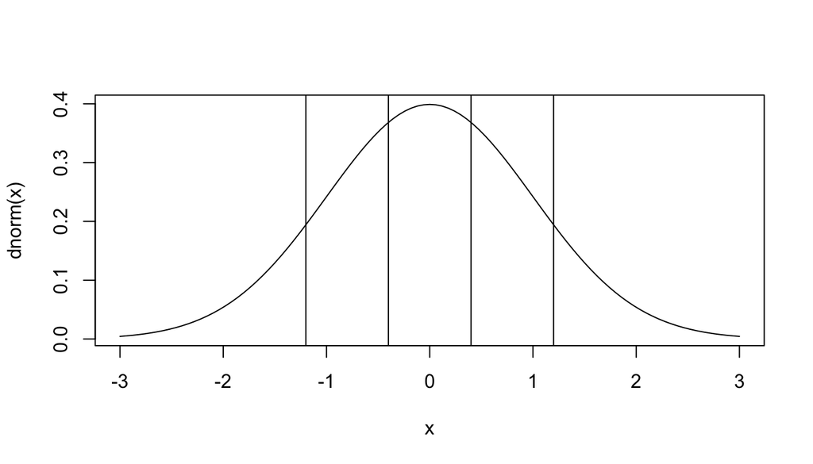

```r
cuts <- c(-Inf, -1.2, -0.4, 0.4, 1.2, Inf)

curve(dnorm, from = -3, to = 3)
abline(v = cuts)
```

## Let’s perform a t-test!

```r
set.seed(123)

effect_size <- 0.7
treatment   <- rnorm(24, mean = effect_size)
control     <- rnorm(24, mean = 0)

treatCut <- as.numeric(cut(treatment, cuts))
contrCut <- as.numeric(cut(control,  cuts))

t.test(treatment, control)$p.value
```

```
## [1] 0.02382654
```

```r
t.test(treatCut, contrCut)$p.value
```

```
## [1] 0.09583241
```

How confident are we in this result?

## Monte carlo simulation

```r
# Initialise results object
result <- matrix(FALSE, nrow = 100000, ncol = 2)

for (i in 1:100000) {
  # generate a dataset of interest
  treatment <- rnorm(24, .7)
  control   <- rnorm(24)
  treatCut <- as.numeric(cut(treatment, cuts))
  contrCut <- as.numeric(cut(control,  cuts))

  # perform your method on this dataset
  treatp <- t.test(treatment, control)$p.value
  contrp <- t.test(treatCut, contrCut)$p.value

  # Save the values you are interested in
  result[i,1] <- treatp < 0.05
  result[i,2] <- contrp < 0.05
}

colMeans(result)
```

```
## [1] 0.66311 0.62295
```

## Conclusions

- Monte Carlo simulations can estimate difficult-to-calculate probabilities
- iterations yield less bias (law of large numbers)
- Monte Carlo simulations can be used to test the statistical properties of methodologies
  - At what sample size does my method fail?
  - How much of a violation of sphericity is allowed in an ANOVA?
  - What is the power of a nonparametric vs. a parametric test?
  - How biased is my estimation procedure?
  - What is the effect on power if I do this sub-optimal thing?